# Zealbert_FinalHomeworkCode_04

Zoe Albert

10/28/2021

## R Markdown

[output not shown]

```r
z.prop.test <-function(p1,n1,p0,p2=NULL,n2=NULL,conf.level=0.95,alternative="two.sided")
  {if(p1 == 0){return(0)}else {if((n1 * p1 < 5) | (n1 * (1-p1) > 5)){return(c("Warning: Not Normal", (p1-p0) / sqrt((p0 * (1-p0))/n1)))} else(return((p1-p0) / sqrt((p0 * (1-p0))/n1)))}}
###I don't fully understand why and how you know to do different lines.  It seems like this doesn't matter. Spacing doesn't matter.
###Only works with two ==
###Just plugging in what the instructions said.  Unsure if all right, especially second half.  This should be for one sample, following these rules of thumb.
###two sample test
z.test.2 <- function(p1,n1,p0,p2,n2,conf.level=0.95,alternative="two.sided") {if(p1 == 0){return(0)}
else {if((n1 * p1 < 5) | (n1 * (1-p1) < 5)){return(c("Warning: This aint normal", (p1-p0) / sqrt((p0 * (1-p0))/n1)))}
else(return((p1-p0) / sqrt((p0 * (1-p0))/n1)))}
  ###I realized I could have it give me funny warnings, so I added this.  Kind of makes coding more fun, no?
  ###for second sample
if(p2 == 0){return(0)}else {if((n2 * p2 < 5) | (n2 * (1-p2) < 5)){return(c("Warning: A real not normal situation you got yourself here, buddy", (p2-p0) / sqrt((p0 * (1-p0))/n2)))}else(return((p2-p0) / sqrt((p0 * (1-p0))/n2)))}}
###Note the similarity between the two
###Do I need to test each function?
###I really struggling with reading all of the instructions and knowing what order I should do things in... I am also not sure what I missed if anything and why...
###I am not getting any errors when I run the chunk.
###This function isn't working:   return(list(z,p,ci))  Maybe I am running it too early?
###This is a good way to add the label:
     ###  cat( "Z_score =", Z.two.sample <- Z.two.sample, "\n",
     ###"CI =", CI.two.sample <- CI.two.sample, "\n",
     ###"P-Value =", P.Value <- P.Value, "\n") }
###IF YOU TYPE IN THE NAME OF A FUNCTION, WITH NO PARENTHESIS, AND PRESS ENTER, YOU CAN SEE WHAT IS "UNDER THE HOOD".



###This is the information that I find for it online: prop.test(x, n, p = NULL, alternative = “two.sided”, correct = TRUE)
#########x: a vector of counts of successes
#########n: a vector of count trials
#########alternative: a character string specifying the alternative hypothesis
#########correct: a logical indicating whether Yates’ continuity correction should be applied where possible
#########Note that, by default, the function prop.test() used the Yates continuity correction, which is really important if either the expected successes or failures is < 5. If you don’t want the correction, use the additional argument correct = FALSE in prop.test() function. The default value is TRUE. (This option must be set to FALSE to make the test mathematically equivalent to the uncorrected z-test of a proportion.)
```

*you should be able to make one function defining all variables, for the one and two sample test (for one sample, you will set: if (is.null(p2) == TRUE || is.null(n2) == TRUE)) and your “else” will be when they are not null (i.e. you have p2 and n2 values) then define the upper and lower CI for when p2 and n2 are and are not null.*

```r
###one sample: sample proportion is 10%, size is 100, expected population proportion is 25%. Is this anything???
###two sample: proportion is 50% size is 500 expected is 30%

z.prop.test(p1=.10,n1=100,p0=.25,p2=NULL,n2=NULL,conf.level=0.95,alternative="two.sided")
```

```
## [1] "Warning: Not Normal" "-3.46410161513775"
```

```r
z.prop.test(p1=.50,n1=500,p0=.30,p2=NULL,n2=NULL,conf.level=0.95,alternative="two.sided")
```

```
## [1] "Warning: Not Normal" "9.75900072948533"
```

```r
###two sample test:
z.test.2(p1=.10,n1=100,p0=.25,p2=.15,n2=50,conf.level=0.95,alternative="two.sided")
```

```
## [1] -3.464102
```

```r
z.test.2(p1=.50,n1=500,p0=.30,p2=.15,n2=50,conf.level=0.95,alternative="two.sided")
```

```
## [1] 9.759001
```

```r
###What are P2 and n2??????
```

###The function should return a list containing the members Z (the test statistic), P (the appropriate p value), and CI (the two-sided CI with respect to “conf.level” around p1 in the case of a one-sample test and around p2-p1 in the case of a two-sample test). For all test alternatives (“two.sided”, “greater”, “less”), calculate symmetric CIs based on quantiles of the normal distribution rather than worrying about calculating single-limit confidence bounds.

```r
   z.prop.test(p1 = 0.6, n1 = 30, p0 = 0.5, conf.level = 0.95)
```

```
## [1] "Warning: Not Normal" "1.09544511501033"
```

```r
    z.prop.test(p1 = 0.6, n1 = 5, p0 = 0.5, alternative = "less", conf.level = 0.95)
```

```
## [1] "Warning: Not Normal" "0.447213595499958"
```

```r
    z.prop.test(p1 = 0.6, n1 = 30, p0 = 0, p2 = 0.8, n2 = 25, conf.level = 0.95)
```

```
## [1] "Warning: Not Normal" "Inf"
```

```r
    z.prop.test(p1 = 0.6, n1 = 30, p0 = 0.4, n2 = 25, conf.level = 0.95)
```

```
## [1] "Warning: Not Normal" "2.23606797749979"
```

```r
    z.prop.test(p1 = 0.6, n1 = 50, p0 = 0, p2 = 0.8, n2 = 60, alternative = "greater", conf.level = 0.95)
```

```
## [1] "Warning: Not Normal" "Inf"
```

```r
    ###Was hoping my silly not normal error would show up.  Oh well!
    ###MANY MANY MANY THANKS to Diego for helping me with this part.
    ### What does "Inf" mean in the answer??????? I get this for the 3rd and 5th rows.
```

###[2] The dataset from Kamilar and Cooper has in it a large number of variables related to life history and body size. For this exercise, the end aim is to fit a simple linear regression model to predict longevity (MaxLongevity_m) measured in months from species’ brain size (Brain_Size_Species_Mean) measured in grams. Do the following for both longevity~brain size and log(longevity)~log(brain size): Fit the regression model and, using {ggplot2}, produce a scatterplot with the fitted line superimposed upon the data. Append the the fitted model equation to your plot (HINT: use the function geom_text()). Identify and interpret the point estimate of the slope (β1), as well as the outcome of the test associated with the hypotheses H0: β1 = 0; HA: β1 ≠ 0. Also, find a 90 percent CI for the slope (β1) parameter. Using your model, add lines for the 90 percent confidence and prediction interval bands on the plot and add a legend to differentiate between the lines. Produce a point estimate and associated 90 percent PI for the longevity of a species whose brain weight is 800 gm. Do you trust the model to predict observations accurately for this value of the explanatory variable? Why or why not? Looking at your two models, which do you think is better? Why?

###Download the data

```r
library(curl)
f <- curl("https://raw.githubusercontent.com/fuzzyatelin/fuzzyatelin.github.io/master/AN588_Fall21/KamilarAndCooperData.csv")
d <- read.csv(f, header = TRUE, sep = ",", stringsAsFactors = FALSE)
head(d)
```

```
##               Scientific_Name          Family          Genus      Species
## 1 Allenopithecus_nigroviridis Cercopithecidae Allenopithecus nigroviridis
## 2         Allocebus_trichotis Cercopithecidae      Allocebus    trichotis
## 3           Alouatta_belzebul        Atelidae       Alouatta     belzebul
## 4             Alouatta_caraya        Atelidae       Alouatta       caraya
## 5            Alouatta_guariba        Atelidae       Alouatta      guariba
## 6           Alouatta_palliata        Atelidae       Alouatta     palliata
##   Brain_Size_Species_Mean Brain_Size_Female_Mean   Brain_size_Ref
## 1                   58.02                  53.70 Isler et al 2008
## 2                      NA                     NA
## 3                   52.84                  51.19 Isler et al 2008
## 4                   52.63                  47.80 Isler et al 2008
## 5                   51.70                  49.08 Isler et al 2008
## 6                   49.88                  48.04 Isler et al 2008
##   Body_mass_male_mean Body_mass_female_mean Mass_Dimorphism
```

[output cut: 62 more lines]

```r
names(d)
```

```
##  [1] "Scientific_Name"         "Family"
##  [3] "Genus"                   "Species"
##  [5] "Brain_Size_Species_Mean" "Brain_Size_Female_Mean"
##  [7] "Brain_size_Ref"          "Body_mass_male_mean"
##  [9] "Body_mass_female_mean"   "Mass_Dimorphism"
## [11] "Mass_Ref"                "MeanGroupSize"
## [13] "AdultMales"              "AdultFemale"
## [15] "AdultSexRatio"           "Social_Organization_Ref"
## [17] "InterbirthInterval_d"    "Gestation"
## [19] "WeaningAge_d"            "MaxLongevity_m"
## [21] "LitterSz"                "Life_History_Ref"
## [23] "GR_MidRangeLat_dd"       "Precip_Mean_mm"
## [25] "Temp_Mean_degC"          "AET_Mean_mm"
## [27] "PET_Mean_mm"             "Climate_Ref"
## [29] "HomeRange_km2"           "HomeRangeRef"
## [31] "DayLength_km"            "DayLengthRef"
## [33] "Territoriality"          "Fruit"
## [35] "Leaves"                  "Fauna"
## [37] "DietRef1"                "Canine_Dimorphism"
## [39] "Canine_Dimorphism_Ref"   "Feed"
## [41] "Move"                    "Rest"
## [43] "Social"                  "Activity_Budget_Ref"
```

```r
summary (d)
```

```
##  Scientific_Name       Family             Genus             Species
##  Length:213         Length:213         Length:213         Length:213
##  Class :character   Class :character   Class :character   Class :character
##  Mode  :character   Mode  :character   Mode  :character   Mode  :character
##
##
##
##
##  Brain_Size_Species_Mean Brain_Size_Female_Mean Brain_size_Ref
##  Min.   :  1.63          Min.   :  1.66         Length:213
##  1st Qu.: 13.95          1st Qu.: 13.23         Class :character
##  Median : 61.45          Median : 57.20         Mode  :character
##  Mean   : 68.11          Mean   : 65.24
##  3rd Qu.: 88.48          3rd Qu.: 86.80
##  Max.   :491.27          Max.   :480.15
##  NA's   :42              NA's   :48
##  Body_mass_male_mean Body_mass_female_mean Mass_Dimorphism   Mass_Ref
##  Min.   :    31      Min.   :   30.0       Min.   :0.841   Length:213
##  1st Qu.:   865      1st Qu.:  835.5       1st Qu.:1.013   Class :character
##  Median :  4290      Median : 3039.0       Median :1.109   Mode  :character
##  Mean   :  8112      Mean   : 5396.5       Mean   :1.246
##  3rd Qu.:  7815      3rd Qu.: 6390.0       3rd Qu.:1.409
##  Max.   :170400      Max.   :97500.0       Max.   :2.688
##  NA's   :18          NA's   :18            NA's   :18
##  MeanGroupSize     AdultMales      AdultFemale     AdultSexRatio
##  Min.   : 1.00   Min.   : 0.900   Min.   : 1.000   Min.   : 0.500
##  1st Qu.: 4.00   1st Qu.: 1.000   1st Qu.: 1.000   1st Qu.: 1.000
##  Median : 7.80   Median : 1.500   Median : 2.900   Median : 1.450
##  Mean   :15.06   Mean   : 2.516   Mean   : 5.049   Mean   : 2.305
##  3rd Qu.:18.50   3rd Qu.: 3.100   3rd Qu.: 7.100   3rd Qu.: 2.770
##  Max.   :90.00   Max.   :16.000   Max.   :25.200   Max.   :15.600
##  NA's   :60      NA's   :68       NA's   :68       NA's   :84
##  Social_Organization_Ref InterbirthInterval_d   Gestation       WeaningAge_d
##  Length:213              Min.   : 144.5       Min.   : 59.99   Min.   :  40.0
##  Class :character        1st Qu.: 365.0       1st Qu.:142.00   1st Qu.: 122.4
##  Mode  :character        Median : 476.9       Median :165.04   Median : 237.7
##                          Mean   : 572.1       Mean   :163.47   Mean   : 310.0
##                          3rd Qu.: 741.4       3rd Qu.:180.75   3rd Qu.: 383.4
##                          Max.   :2007.5       Max.   :256.00   Max.   :1260.8
##                          NA's   :103          NA's   :75       NA's   :95
```

[output cut: 41 more lines]

```
##  Min.   : 9.00   Min.   : 3.00   Min.   : 4.00   Min.   : 0.900
##  1st Qu.:21.75   1st Qu.:14.93   1st Qu.:18.38   1st Qu.: 3.500
##  Median :33.30   Median :21.00   Median :30.48   Median : 5.400
##  Mean   :33.08   Mean   :21.67   Mean   :34.26   Mean   : 7.369
##  3rd Qu.:43.08   3rd Qu.:26.90   3rd Qu.:52.40   3rd Qu.:10.000
##  Max.   :63.90   Max.   :70.60   Max.   :78.50   Max.   :23.500
##  NA's   :141     NA's   :143     NA's   :143     NA's   :136
##  Activity_Budget_Ref
##  Length:213
##  Class :character
##  Mode  :character
##
##
##
##
```

```r
###Is this right as a means of loading?  I think I feel pretty confident about this one.
```

###For this exercise, the end aim is to fit a simple linear regression model to predict longevity (MaxLongevity_m) measured in months from species’ brain size (Brain_Size_Species_Mean) measured in grams. Do the following for both longevity~brain size and log(longevity)~log(brain size):

###HOW TO ADD A REGRESSION LINE: https://stackoverflow.com/questions/7549694/add-regression-line-equation-and-r2-on-graph

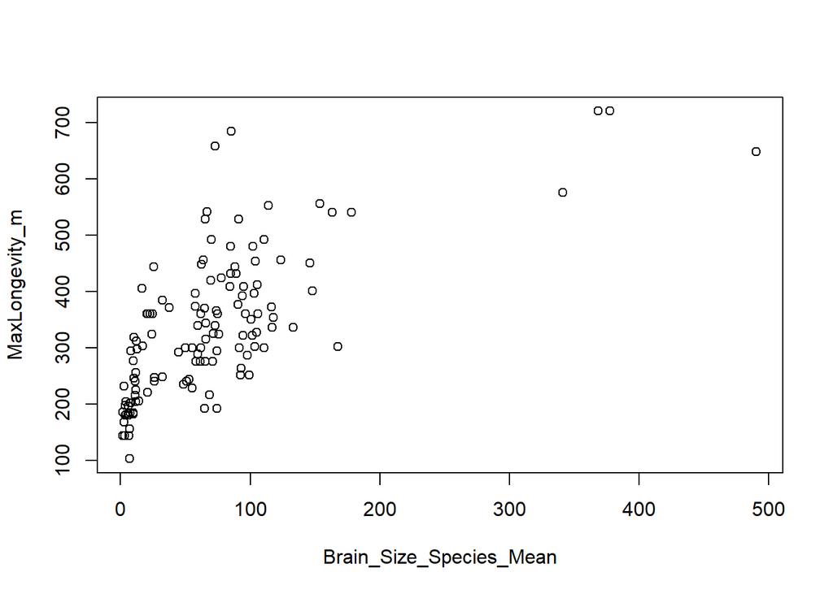

```r
plot(data = d, MaxLongevity_m ~ Brain_Size_Species_Mean)
```

```r
###What even is this graph.  A whole hodgepodge is what it is.
```

```r
model <- lm(data = d, MaxLongevity_m ~ Brain_Size_Species_Mean)
summary(model)
```

```
##
## Call:
## lm(formula = MaxLongevity_m ~ Brain_Size_Species_Mean, data = d)
##
## Residuals:
##     Min      1Q  Median      3Q     Max
## -198.27  -61.92  -17.78   56.16  331.36
##
## Coefficients:
##                         Estimate Std. Error t value Pr(>|t|)
## (Intercept)             248.9523    11.1111   22.41   <2e-16 ***
## Brain_Size_Species_Mean   1.2180     0.1101   11.06   <2e-16 ***
## ---
## Signif. codes:  0 '***' 0.001 '**' 0.01 '*' 0.05 '.' 0.1 ' ' 1
##
## Residual standard error: 90.91 on 126 degrees of freedom
##   (85 observations deleted due to missingness)
## Multiple R-squared:  0.4928, Adjusted R-squared:  0.4887
## F-statistic: 122.4 on 1 and 126 DF,  p-value: < 2.2e-16
```

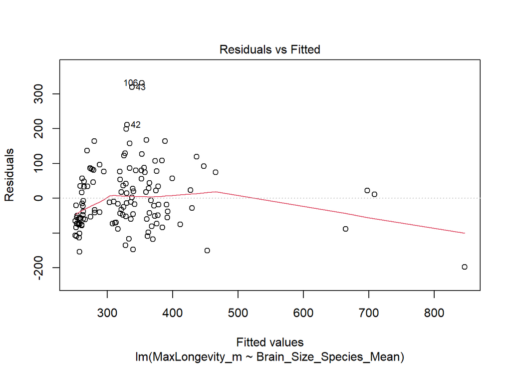

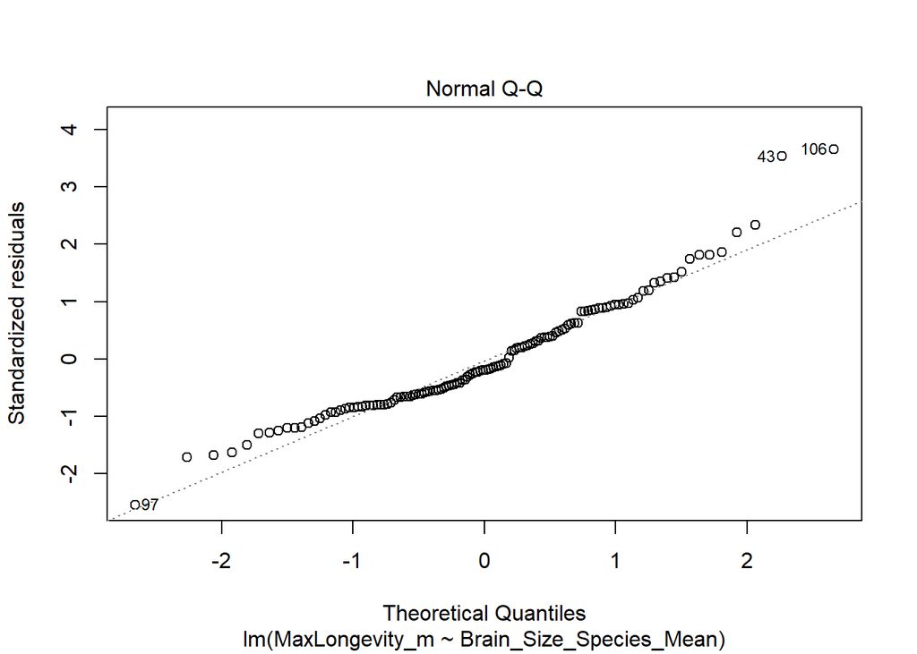

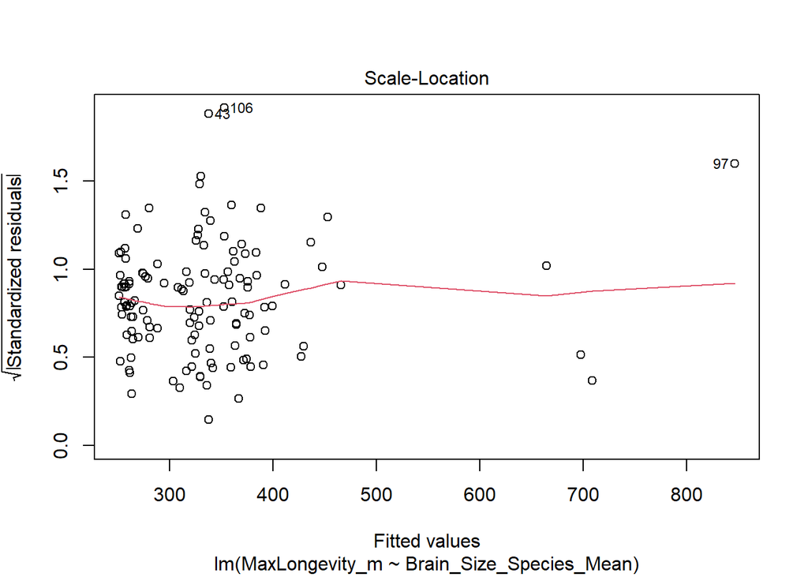

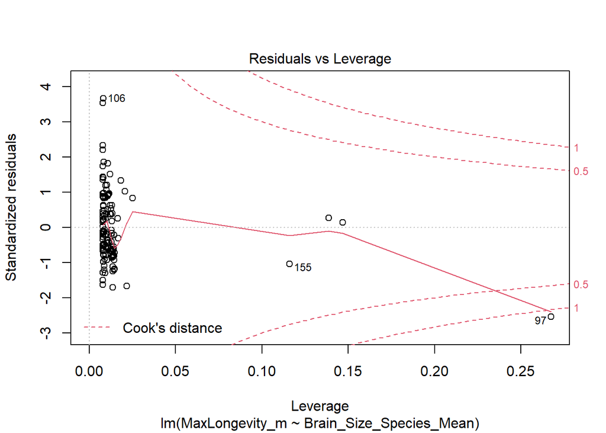

```r
plot(model)
```

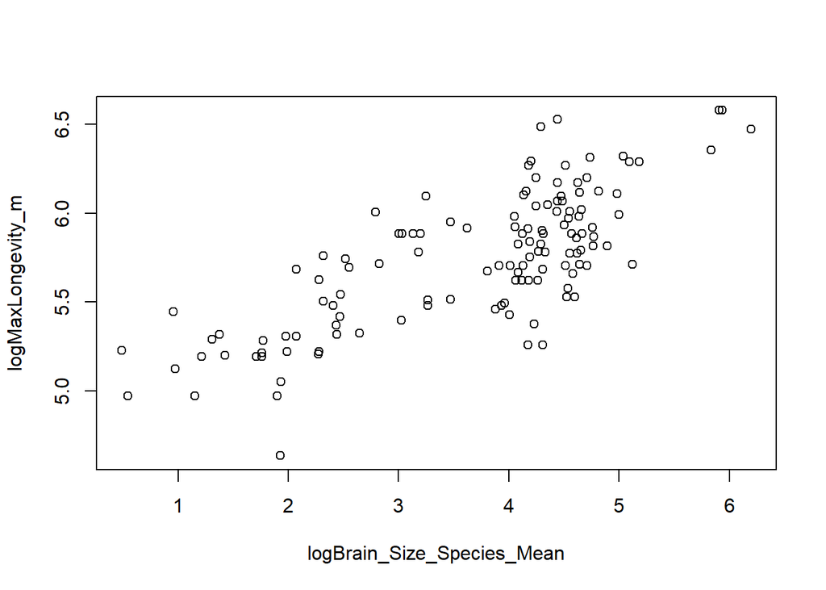

```r
d$logMaxLongevity_m <- log(d$MaxLongevity_m)
d$logBrain_Size_Species_Mean <- log(d$Brain_Size_Species_Mean)
plot(data = d, logMaxLongevity_m ~ logBrain_Size_Species_Mean)
```

```r
model <- lm(data = d, logMaxLongevity_m ~ logBrain_Size_Species_Mean)
summary(model)
```

```
##
## Call:
## lm(formula = logMaxLongevity_m ~ logBrain_Size_Species_Mean,
##     data = d)
##
## Residuals:
##     Min      1Q  Median      3Q     Max
## -0.6955 -0.1750 -0.0097  0.1788  0.6084
##
## Coefficients:
##                            Estimate Std. Error t value Pr(>|t|)
## (Intercept)                 4.87895    0.06907   70.63   <2e-16 ***
## logBrain_Size_Species_Mean  0.23415    0.01781   13.15   <2e-16 ***
## ---
## Signif. codes:  0 '***' 0.001 '**' 0.01 '*' 0.05 '.' 0.1 ' ' 1
##
## Residual standard error: 0.2485 on 126 degrees of freedom
##   (85 observations deleted due to missingness)
## Multiple R-squared:  0.5784, Adjusted R-squared:  0.5751
## F-statistic: 172.9 on 1 and 126 DF,  p-value: < 2.2e-16
```

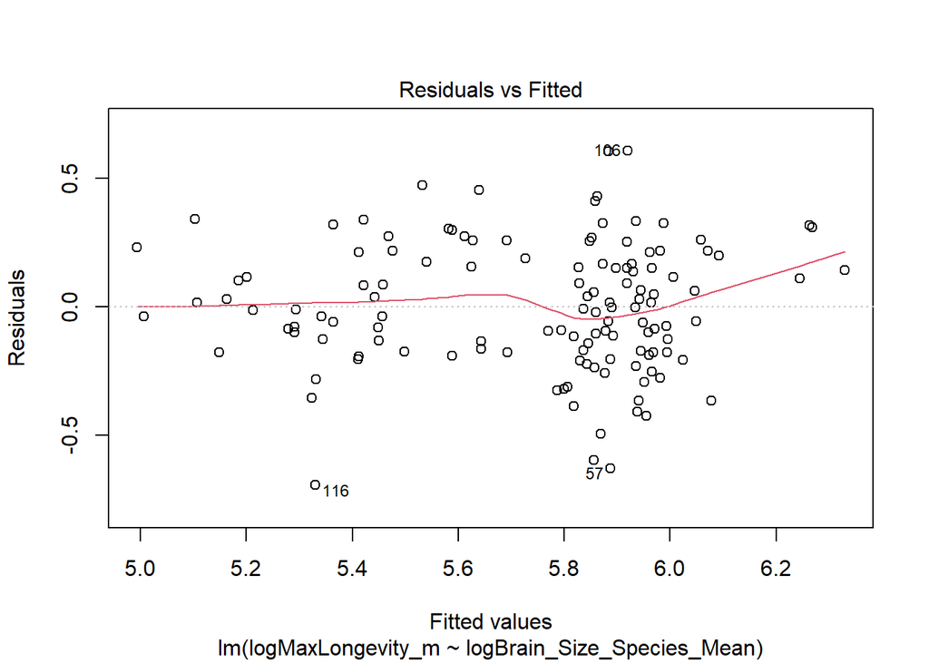

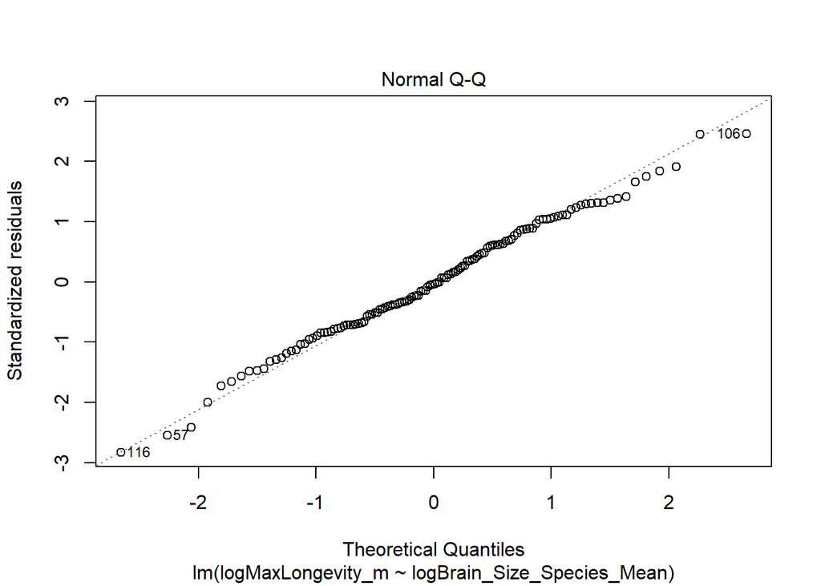

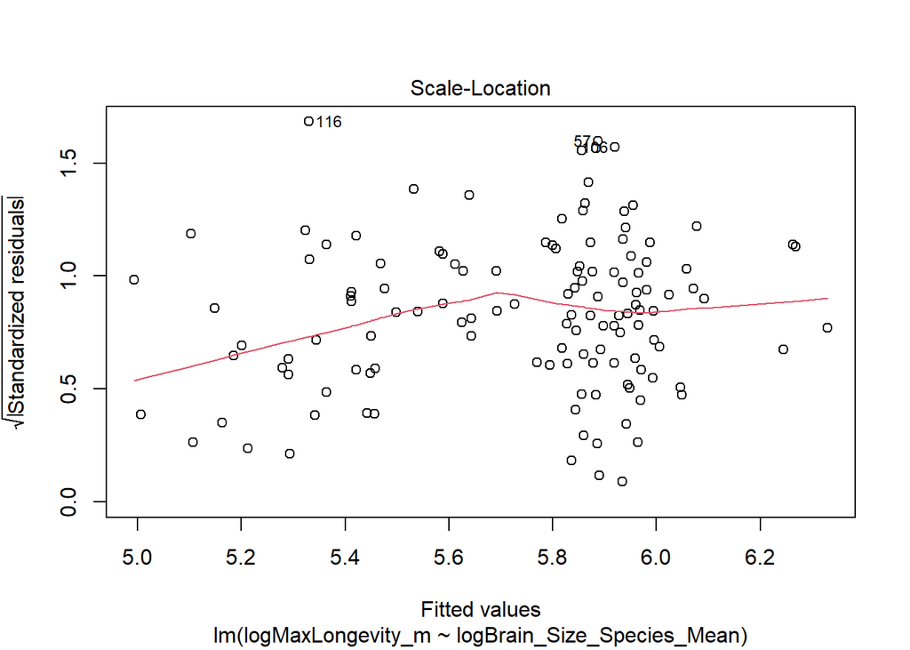

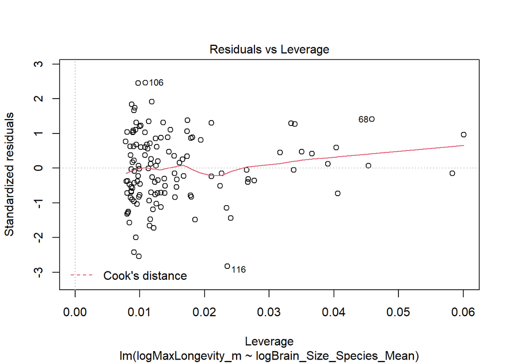

```r
plot(model)
```

```r
###I can just click through to see all the graphs.
```

###Identify and interpret the point estimate of the slope (β1), as well as the outcome of the test associated with the hypotheses H0: β1 = 0; HA: β1 ≠ 0. ###Run a line in order to find the slope.

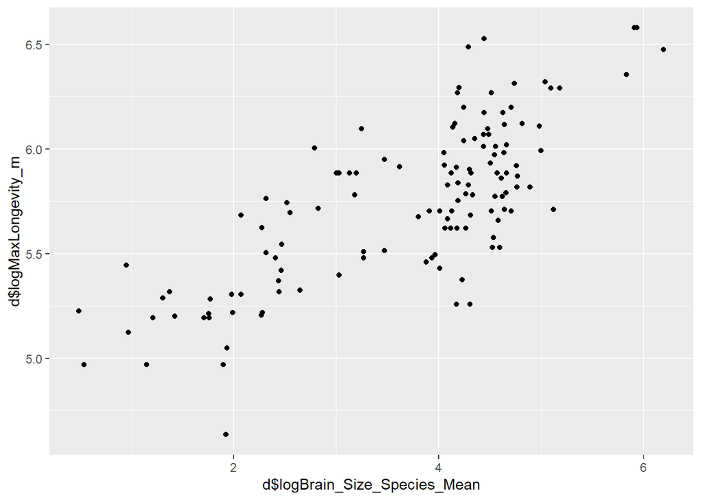

```r
library(ggplot2)
g <- ggplot(data = d, aes(x = d$logBrain_Size_Species_Mean, y = d$logMaxLongevity_m)) + geom_point()
g
```

```r
###Kind of positive correlation.
###Should I have done curl?
```

*Don’t forget to add a line with geom_smooth(). also plot your not-logged data for comparison (also with ggplot). You can add the equation using annotated(“text”, label = “your equation”) with the equation being based off of the interpretted coefficients given in your modle summary.*

```r
b <- d$logBrain_Size_Species_Mean
l <- d$logMaxLongevity_m
m <- lm(l ~ b)
m
```

```
##
## Call:
## lm(formula = l ~ b)
##
## Coefficients:
## (Intercept)            b
##      4.8790       0.2341
```

```r
###Coefficients:Intercept = 4.8790 and b = 0.2341
```

*Intercept is the y intercept, b is the slope, B0 and B1 respectively.*

```r
library(lmodel2)
###load the lmodel2 package
mII <- lmodel2(MaxLongevity_m ~ Brain_Size_Species_Mean, data = d, range.y = "relative", range.x = "relative",
    nperm = 1000)
mII
```

```
##
## Model II regression
##
## Call: lmodel2(formula = MaxLongevity_m ~ Brain_Size_Species_Mean, data
## = d, range.y = "relative", range.x = "relative", nperm = 1000)
##
## n = 128   r = 0.7019753   r-square = 0.4927693
## Parametric P-values:   2-tailed = 2.685909e-20    1-tailed = 1.342954e-20
## Angle between the two OLS regression lines = 17.35978 degrees
##
## Permutation tests of OLS, MA, RMA slopes: 1-tailed, tail corresponding to sign
## A permutation test of r is equivalent to a permutation test of the OLS slope
## P-perm for SMA = NA because the SMA slope cannot be tested
##
## Regression results
##   Method Intercept    Slope Angle (degrees) P-perm (1-tailed)
## 1    OLS  248.9523 1.217990        50.61316       0.000999001
## 2     MA  185.9393 2.121962        64.76728       0.000999001
## 3    SMA  212.9069 1.735090        60.04348                NA
## 4    RMA  204.1621 1.860542        61.74296       0.000999001
##
## Confidence intervals
##   Method 2.5%-Intercept 97.5%-Intercept 2.5%-Slope 97.5%-Slope
## 1    OLS       226.9637        270.9408   1.000130    1.435851
## 2     MA       154.8589        209.0668   1.790180    2.567837
## 3    SMA       196.7709        227.1436   1.530853    1.966575
## 4    RMA       177.9787        225.1284   1.559764    2.236164
##
## Eigenvalues: 19247.81 2287.528
##
## H statistic used for computing C.I. of MA: 0.004757621
```

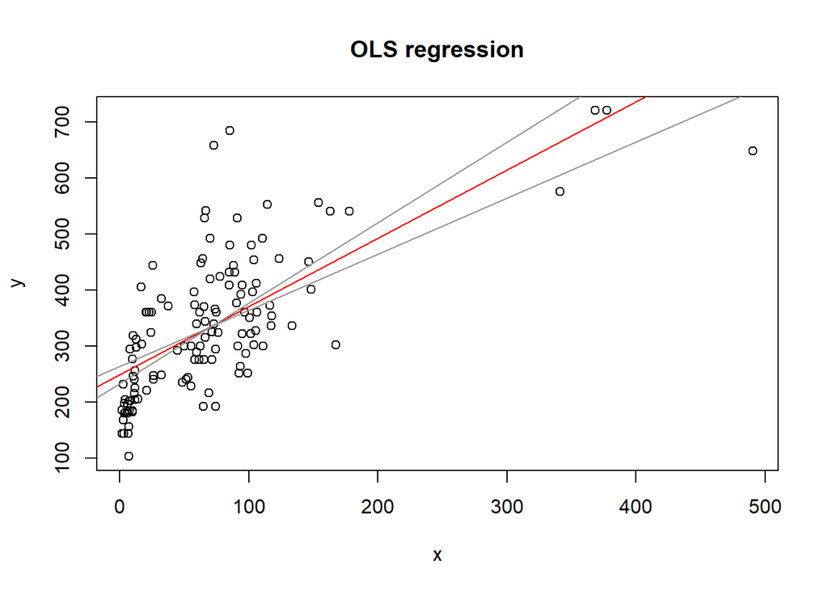

```r
plot(mII, "OLS")
```